# TDLNM

Daniel Mork, Colorado State University

2021-09-01

This document illustrates the main features of `tdlnm` within the `dlmtree` package. Additional information regarding the statistical methodology and computational details are given in [Mork & Wilson (2021)](https://arxiv.org/abs/2010.06147).

## Overview of DLNMs

The distributed lag nonlinear model (DLNM) is a tool for estimating an exposure-response function due to a series of possibly correlated, lagged exposures. In particular, we consider the exposure-response function $f(\mathbf{x}_i)=\sum_t w(x_{it},t)$ where $w(x_{it},t)$ represents the DLNM.

## TDLNM

Often, $w$ is constrained to vary smoothly over time and estimated via spline-based methods. TDLNM allows for smoothness, but also enables a `hard’ cutoff in exposure effects at a given timepoint, which allows for more precision in identifying periods of effect/no-effect.

TDLNM method operates using a set of regression trees that each assume piecewise constant relationships across the exposure-time space. TDLNM outperforms spline-based models when the exposure-time surface is not smooth and performs similarly in smooth settings. TDLNM also produces lower variance estimates while maintain high coverage and more precisely identifies critical windows within the exposure-time surface.

## Basic example

### Installation

To install package `dlmtree`, use the `devtools` package and run function `install_github`.

```r
library(devtools)
install_github("danielmork/dlmtree")
```

### Data

For this example we will use a data simulation available in the `dlmtree` package.

```r
library(dlmtree)
set.seed(1)
D <- sim.tdlnm(effect = "A", error.to.signal = 1)
# Also try effects B (linear), C (logistic), and D (logistic and smooth in time)
```

### Model

- Define a fixed effects formula using data fed to the `data` parameter
- Input `exposure.data` as a matrix, where the columns relate to the time periods of exposure (this could also be interpreted as lags where the first column is the most recent exposure)
- Specify `exposure.se` for a smooth effect (TDLNMse) in exposure-concentration, in our paper we used half the standard deviation of the exposure data, which gave consistent results across a range of simulation scenarios
- Define `exposure.splits` across the range of exposure-concentration values. This could be given as a fixed set of values, or a single value which will split evenly across the quantiles of the exposure data. Setting this to $0$ results in a DLM (linear effects)
- Run the model for the desired number of iterations. We recommend using $20$ trees and $\geq15000$ iterations thinned to every tenth iteration following $\geq5000$ burn-in iterations. Model convergence can be checked by comparing the consistency of results across multiple runs
- Our method currently supports a continuous or binary outcome by specifying ‘gaussian’ or ‘logit’ in the `family` parameter

```r
splits <- seq(min(D$exposure), max(D$exposure), length.out = 52)
res <- tdlnm(formula = y ~ .,
             data = D$dat,
             exposure.data = as.matrix(D$exposure),
             #exposure.se = sd(D$exposure)/2,
             exposure.splits = splits,
             n.trees = 20, n.burn = 2000, n.iter = 5000, n.thin = 5,
             family = "gaussian")
```

```
## Preparing data...
## exposure.splits entered as numeric vector, assuming values are exposure splitting points
## Burn-in % complete
## [0--------25--------50--------75--------100]
##  ''''''''''''''''''''''''''''''''''''''''''
## MCMC iterations (est time: 5 seconds)
## [0--------25--------50--------75--------100]
##  ''''''''''''''''''''''''''''''''''''''''''
## Compiling results...
```

### Summary

- Summarize results using the `summary` function
- Input ‘cenval’ will center the DLNM surface at a specified exposure concentration
- The ‘pred.at’ input specifies a range of exposure values to make predictions, if empty this default to the splitting values
- ‘conf.level’ will allow for different credible interval probabilities
- Note that in the instance of a binary outcome, results are given as log(odds). This can be converted to a standard odds ratio using `exp(res_sum$gamma.mean)` and `exp(res_sum$gamma.ci)`

```r
res_sum <- summary(res,
                   cenval = D$cenval,
                   pred.at = seq(min(D$exposure), max(D$exposure), length.out = 100),
                   conf.level = 0.95)
```

```
## Centered DLNM at exposure value 1
```

```r
res_sum
```

```
## ---
## TDLNM summary
##
## Model run info
## - 20 trees
## - 2000 burn-in iterations
## - 5000 post-burn iterations
## - 5 thinning factor
## - 0.95 confidence level
##
## Fixed effect coefficients:
##               Mean Lower.Bound Upper.Bound
## (Intercept) -4.150     -25.682      17.959
## *c1          0.683       0.586       0.785
## *c2          1.288       1.198       1.386
## *c3          0.301       0.200       0.400
## *c4         -0.994      -1.084      -0.904
## *c5         -0.575      -0.673      -0.475
## *b1         -2.451      -2.646      -2.245
## *b2         -1.569      -1.770      -1.366
## *b3          1.723       1.522       1.923
## *b4          0.580       0.379       0.776
## *b5         -1.512      -1.717      -1.304
## ---
## * = CI does not contain zero
##
## DLNM effect:
## range = [-1.05, 0.064]
## signal-to-noise = 1.072
## critical windows: 11-15
```

### Fixed Effects

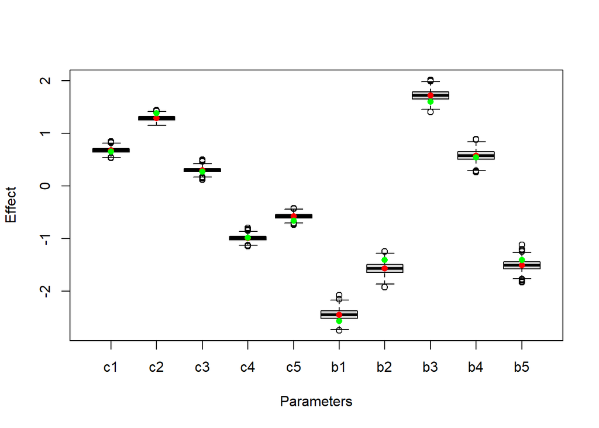

```r
boxplot(res$gamma[,-1], xlab = "Parameters", ylab = "Effect") # Boxplot estimated effects
points(1:10, res_sum$gamma.mean[-1], col = "red", pch = 16) # Posterior mean
points(1:10, D$params, col = "green", pch = 16) # Green dots = truth
```

### Plot DLNM exposure-time response surface

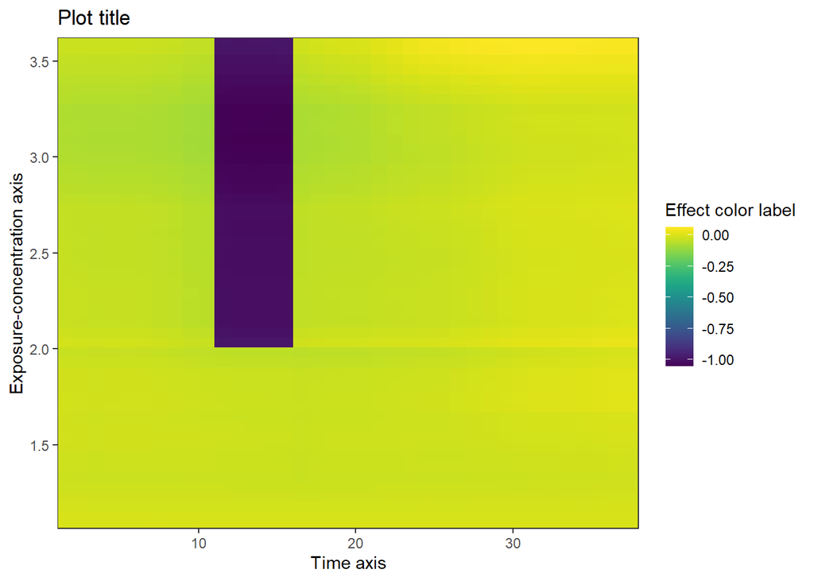

```r
plot(res_sum,
     plot.type = "mean", # (default), also 'se', 'ci-min', 'ci-max', 'slice'
     main = "Plot title",
     xlab = "Time axis",
     ylab = "Exposure-concentration axis",
     flab = "Effect color label",
     start.time = 1) # change to reorient x-axis
```

#### Slice at exposure-concentration = 3

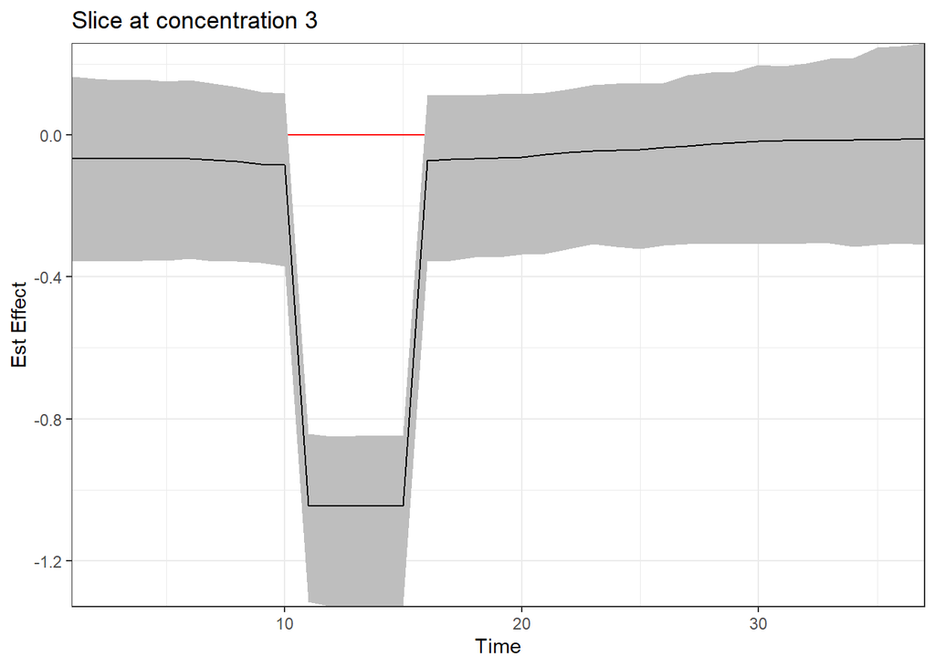

```r
plot(res_sum, plot.type = "slice", val = 3, main = "Slice at concentration 3")
```

#### Slice at time = 13

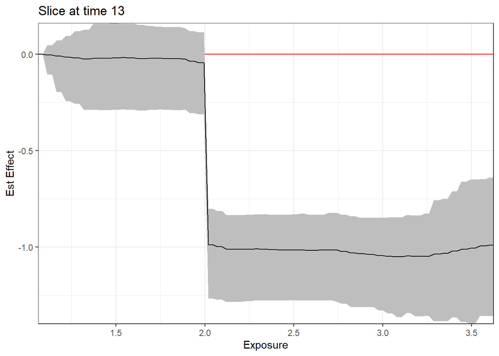

```r
plot(res_sum, plot.type = "slice", time = 13, main = "Slice at time 13")
```

### Compare to truth

```r
truth <- D$dlnm.fun(sapply(1:37, function(i) res_sum$pred.at), D$cenval, F)
# RMSE
sqrt(mean((res_sum$matfit - truth)^2))
```

```
## [1] 0.0318009
```

```r
# Coverage
mean(res_sum$cilower < truth & res_sum$ciupper > truth)
```

```
## [1] 0.98
```

```r
# True positive effect classification
(length(which(res_sum$cilower > 0 & truth > 0)) +
    length(which(res_sum$ciupper < 0 & truth < 0))) /
  length(which(truth != 0))
```

```
## [1] 1
```

```r
# False positive effect classification
(length(which(res_sum$cilower > 0 & truth == 0)) +
    length(which(res_sum$ciupper < 0 & truth == 0))) /
  length(which(truth == 0))
```

```
## [1] 0
```